# Construct Single-Hierarchical P/NBD Model for Online Retail Transaction Data

Author

Mick Cooney mickcooney@gmail.com

Published

February 16, 2024

# 1 Load and Construct Datasets

We start by modelling the P/NBD model using our synthetic datasets before we try to model real-life data.

## 1.1 Load Online Retail Data

We now want to load the online retail transaction data.

```r
customer_cohortdata_tbl <- read_rds("data/onlineretail_cohort_tbl.rds")
customer_cohortdata_tbl |> glimpse()
```

```
Rows: 5,852
Columns: 5
$ customer_id     <chr> "12346", "12347", "12348", "12349", "12350", "12351", …
$ cohort_qtr      <chr> "2010 Q1", "2010 Q4", "2010 Q3", "2010 Q2", "2011 Q1",…
$ cohort_ym       <chr> "2010 03", "2010 10", "2010 09", "2010 04", "2011 02",…
$ first_tnx_date  <date> 2010-03-02, 2010-10-31, 2010-09-27, 2010-04-29, 2011-…
$ total_tnx_count <int> 3, 8, 5, 3, 1, 1, 9, 2, 1, 2, 6, 2, 5, 10, 6, 4, 10, 2…
```

```r
customer_transactions_tbl <- read_rds("data/onlineretail_transactions_tbl.rds")
customer_transactions_tbl |> glimpse()
```

```
Rows: 36,658
Columns: 5
$ tnx_timestamp <dttm> 2009-12-01 07:45:00, 2009-12-01 07:45:59, 2009-12-01 09…
$ orig_id       <chr> "13085", "13085", "13078", "15362", "18102", "12682", "1…
$ customer_id   <fct> 13085, 13085, 13078, 15362, 18102, 12682, 18087, 18087, …
$ invoice_id    <chr> "489434", "489435", "489436", "489437", "489438", "48943…
$ tnx_amount    <dbl> 505.30, 145.80, 630.33, 310.75, 2286.24, 372.30, 50.40, …
```

```r
customer_subset_id <- read_rds("data/onlineretail_customer_subset_ids.rds")
customer_subset_id |> glimpse()
```

```
 Factor w/ 5852 levels "13085","13078",..: 2 3 8 10 14 16 17 21 27 30 ...
```

## 1.2 Load Derived Data

```r
customer_summarystats_tbl <- read_rds("data/onlineretail_customer_summarystats_tbl.rds")

obs_fitdata_tbl   <- read_rds("data/onlineretail_obs_fitdata_tbl.rds")
obs_validdata_tbl <- read_rds("data/onlineretail_obs_validdata_tbl.rds")

customer_fit_stats_tbl <- obs_fitdata_tbl |>
  rename(x = tnx_count)
```

## 1.3 Load Subset Data

We also want to construct our data subsets for the purposes of speeding up our valuations.

```r
customer_fit_subset_tbl <- obs_fitdata_tbl |>
  filter(customer_id %in% customer_subset_id)

customer_fit_subset_tbl |> glimpse()
```

```
Rows: 1,000
Columns: 6
$ customer_id    <fct> 13078, 15362, 14110, 13758, 17592, 13767, 17238, 17700,…
$ first_tnx_date <dttm> 2009-12-01 09:05:59, 2009-12-01 09:08:00, 2009-12-01 0…
$ last_tnx_date  <dttm> 2010-11-30 13:17:59, 2010-09-17 10:36:59, 2010-09-30 1…
$ tnx_count      <dbl> 30, 1, 20, 6, 0, 35, 14, 9, 4, 9, 78, 2, 17, 5, 22, 2, …
$ t_x            <dbl> 52.02500, 41.43740, 43.32966, 51.72589, 0.00000, 52.034…
$ T_cal          <dbl> 52.08869, 52.08849, 52.08433, 52.08274, 52.07847, 52.07…
```

```r
customer_valid_subset_tbl <- obs_validdata_tbl |>
  filter(customer_id %in% customer_subset_id)

customer_valid_subset_tbl |> glimpse()
```

```
Rows: 1,000
Columns: 3
$ customer_id       <fct> 13078, 15362, 14110, 13758, 17592, 13767, 17238, 177…
$ tnx_count         <dbl> 26, 0, 12, 7, 0, 37, 17, 4, 4, 13, 48, 0, 13, 3, 16,…
$ tnx_last_interval <dbl> 52.950000, NA, 52.931151, 51.780853, NA, 53.089286, …
```

We now use these datasets to set the start and end dates for our various validation methods.

```r
dates_lst <- read_rds("data/onlineretail_simulation_dates.rds")

use_fit_start_date <- dates_lst$use_fit_start_date
use_fit_end_date   <- dates_lst$use_fit_end_date

use_valid_start_date <- dates_lst$use_valid_start_date
use_valid_end_date   <- dates_lst$use_valid_end_date
```

We now split out the transaction data into fit and validation datasets.

```r
customer_fit_transactions_tbl <- customer_transactions_tbl |>
  filter(
    customer_id %in% customer_subset_id,
    tnx_timestamp >= use_fit_start_date,
    tnx_timestamp <= use_fit_end_date
    )

customer_fit_transactions_tbl |> glimpse()
```

```
Rows: 4,164
Columns: 5
$ tnx_timestamp <dttm> 2009-12-01 09:05:59, 2009-12-01 09:08:00, 2009-12-01 09…
$ orig_id       <chr> "13078", "15362", "14110", "13758", "17592", "13767", "1…
$ customer_id   <fct> 13078, 15362, 14110, 13758, 17592, 13767, 17238, 17700, …
$ invoice_id    <chr> "489436", "489437", "489443", "489446", "489462", "48946…
$ tnx_amount    <dbl> 630.33, 310.75, 285.06, 996.10, 148.30, 1197.80, 251.10,…
```

```r
customer_valid_transactions_tbl <- customer_transactions_tbl |>
  filter(
    customer_id %in% customer_subset_id,
    tnx_timestamp >= use_valid_start_date,
    tnx_timestamp <= use_valid_end_date
    )

customer_valid_transactions_tbl |> glimpse()
```

```
Rows: 3,422
Columns: 5
$ tnx_timestamp <dttm> 2010-12-01 09:32:00, 2010-12-01 09:59:00, 2010-12-01 10…
$ orig_id       <chr> "15291", "16250", "12431", "13408", "13767", "12791", "1…
$ customer_id   <fct> 15291, 16250, 12431, 13408, 13767, 12791, 17908, 16583, …
$ invoice_id    <chr> "536376", "536388", "536389", "536394", "536395", "53640…
$ tnx_amount    <dbl> 657.60, 452.28, 716.50, 2049.36, 1015.76, 355.20, 486.56…
```

Finally, we want to extract the first transaction for each customer, so we can add this data to assess our models.

```r
customer_initial_tnx_tbl <- customer_fit_transactions_tbl |>
  slice_min(n = 1, order_by = tnx_timestamp, by = customer_id)

customer_initial_tnx_tbl |> glimpse()
```

```
Rows: 1,002
Columns: 5
$ tnx_timestamp <dttm> 2009-12-01 09:05:59, 2009-12-01 09:08:00, 2009-12-01 09…
$ orig_id       <chr> "13078", "15362", "14110", "13758", "17592", "13767", "1…
$ customer_id   <fct> 13078, 15362, 14110, 13758, 17592, 13767, 17238, 17700, …
$ invoice_id    <chr> "489436", "489437", "489443", "489446", "489462", "48946…
$ tnx_amount    <dbl> 630.33, 310.75, 285.06, 996.10, 148.30, 1197.80, 251.10,…
```

We now expand out these initial transactions so that we can append them to our simulations.

```r
sim_init_tbl <- customer_initial_tnx_tbl |>
  transmute(
    customer_id,
    draw_id       = list(1:n_sim),
    tnx_timestamp,
    tnx_amount
    ) |>
  unnest(draw_id)

sim_init_tbl |> glimpse()
```

```
Rows: 2,004,000
Columns: 4
$ customer_id   <fct> 13078, 13078, 13078, 13078, 13078, 13078, 13078, 13078, …
$ draw_id       <int> 1, 2, 3, 4, 5, 6, 7, 8, 9, 10, 11, 12, 13, 14, 15, 16, 1…
$ tnx_timestamp <dttm> 2009-12-01 09:05:59, 2009-12-01 09:05:59, 2009-12-01 09…
$ tnx_amount    <dbl> 630.33, 630.33, 630.33, 630.33, 630.33, 630.33, 630.33, …
```

Before we start on that, we set a few parameters for the workbook to organise our Stan code.

```r
stan_modeldir <- "stan_models"
stan_codedir  <-   "stan_code"
```

# 2 Fit Hierarchical Mean-Lambda, Mean-Mu Model

Our first model puts a hierarchical prior around the mean of both the population $\lambda$, `lambda_mn`, and population $\mu$, `mu_mn`.

Once again we use a Gamma prior for both these parameters

## 2.1 Compile and Fit Stan Model

We now compile this model using `CmdStanR`.

```r
pnbd_twohiermean_stanmodel <- cmdstan_model(
  "stan_code/pnbd_twohier_mean.stan",
  include_paths =   stan_codedir,
  pedantic      =           TRUE,
  dir           =  stan_modeldir
  )
```

We then use this compiled model with our data to produce a fit of the data.

```r
stan_modelname <- "pnbd_onlineretail_twohiermean"
stanfit_prefix <- str_c("fit_", stan_modelname)
stanfit_seed   <- stanfit_seed + 1

stanfit_object_file <- glue("data/{stanfit_prefix}_stanfit.rds")


stan_data_lst <- customer_fit_stats_tbl |>
  select(customer_id, x, t_x, T_cal) |>
  compose_data(
    hier_lambda_mn_p1 = 0.25,
    hier_lambda_mn_p2 = 1.00,

    hier_mu_mn_p1     = 0.10,
    hier_mu_mn_p2     = 1.00,

    lambda_cv         = 1.00,
    mu_cv             = 1.00
    )

if(!file_exists(stanfit_object_file)) {
  pnbd_onlineretail_twohiermean_stanfit <- pnbd_twohiermean_stanmodel$sample(
    data            =                stan_data_lst,
    chains          =                            4,
    iter_warmup     =                          500,
    iter_sampling   =                          500,
    seed            =                 stanfit_seed,
    adapt_delta     =                         0.95,
    save_warmup     =                        FALSE,
    output_dir      =                stan_modeldir,
    output_basename =               stanfit_prefix,
    )

  pnbd_onlineretail_twohiermean_stanfit$save_object(stanfit_object_file, compress = "gzip")

} else {
  pnbd_onlineretail_twohiermean_stanfit <- read_rds(stanfit_object_file)
}

pnbd_onlineretail_twohiermean_stanfit$print()
```

```
  variable      mean    median    sd   mad        q5       q95 rhat ess_bulk
 lp__      -50267.67 -50268.00 70.52 71.61 -50380.21 -50151.39 1.01      679
 lambda_mn      0.10      0.10  0.00  0.00      0.10      0.10 1.02      561
 mu_mn          0.00      0.00  0.00  0.00      0.00      0.00 1.44        8
 lambda[1]      0.25      0.23  0.13  0.13      0.07      0.49 1.00     1668
 lambda[2]      0.50      0.50  0.09  0.09      0.37      0.66 1.00     3098
 lambda[3]      0.03      0.03  0.02  0.02      0.01      0.07 1.00     2141
 lambda[4]      1.38      1.37  0.15  0.16      1.14      1.63 1.00     2216
 lambda[5]      0.32      0.32  0.07  0.08      0.21      0.45 1.00     2710
 lambda[6]      0.24      0.24  0.06  0.06      0.15      0.35 1.00     3040
 lambda[7]      0.05      0.04  0.03  0.03      0.01      0.10 1.00     3348
 ess_tail
     1052
     1047
       18
     1220
     1386
     1276
     1333
     1447
     1407
     1380

 # showing 10 of 12722 rows (change via 'max_rows' argument or 'cmdstanr_max_rows' option)
```

We have some basic HMC-based validity statistics we can check.

```r
pnbd_onlineretail_twohiermean_stanfit$cmdstan_diagnose()
```

```
Processing csv files: /home/rstudio/btydwork/stan_models/fit_pnbd_onlineretail_twohiermean-1.csv, /home/rstudio/btydwork/stan_models/fit_pnbd_onlineretail_twohiermean-2.csv, /home/rstudio/btydwork/stan_models/fit_pnbd_onlineretail_twohiermean-3.csv, /home/rstudio/btydwork/stan_models/fit_pnbd_online…

Checking sampler transitions treedepth.
Treedepth satisfactory for all transitions.

Checking sampler transitions for divergences.
No divergent transitions found.

Checking E-BFMI - sampler transitions HMC potential energy.
E-BFMI satisfactory.

Effective sample size satisfactory.

The following parameters had split R-hat greater than 1.05:
  mu_mn, mu[581], beta
Such high values indicate incomplete mixing and biased estimation.
You should consider regularizating your model with additional prior information or a more effective parameterization.

Processing complete.
```

## 2.2 Visual Diagnostics of the Sample Validity

Now that we have a sample from the posterior distribution we need to create a few different visualisations of the diagnostics.

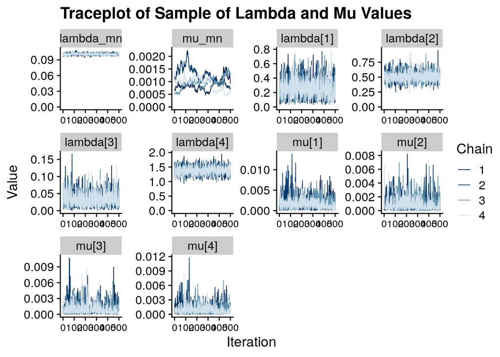

```r
parameter_subset <- c(
  "lambda_mn", "mu_mn",
  "lambda[1]", "lambda[2]", "lambda[3]", "lambda[4]",
  "mu[1]",     "mu[2]",     "mu[3]",     "mu[4]"
  )

pnbd_onlineretail_twohiermean_stanfit$draws(inc_warmup = FALSE) |>
  mcmc_trace(pars = parameter_subset) +
  expand_limits(y = 0) +
  labs(
    x = "Iteration",
    y = "Value",
    title = "Traceplot of Sample of Lambda and Mu Values"
    ) +
  theme(axis.text.x = element_text(size = 10))
```

We also check $N_{eff}$ as a quick diagnostic of the fit.

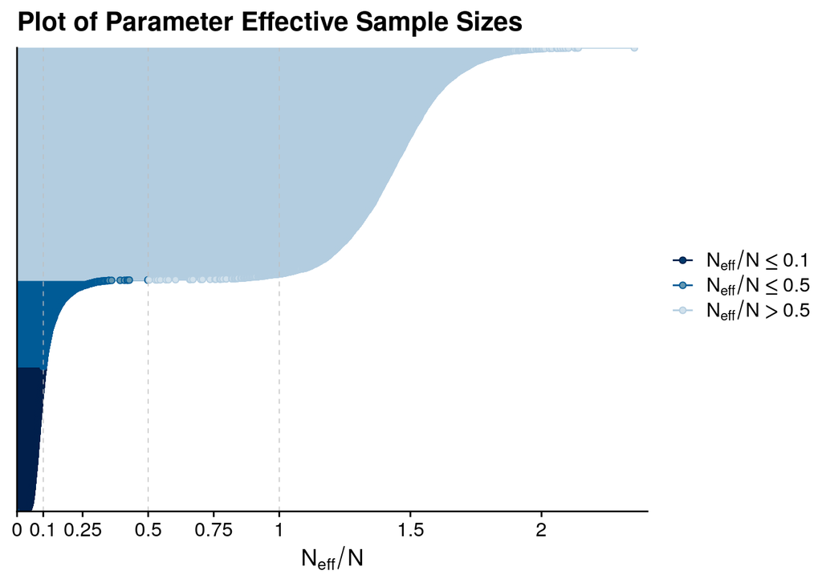

```r
pnbd_onlineretail_twohiermean_stanfit |>
  neff_ratio(pars = c("lambda_mn", "mu_mn", "lambda", "mu")) |>
  mcmc_neff() +
    ggtitle("Plot of Parameter Effective Sample Sizes")
```

Finally, we want to check out the energy diagnostic, which is often indicative of problems with the posterior mixing.

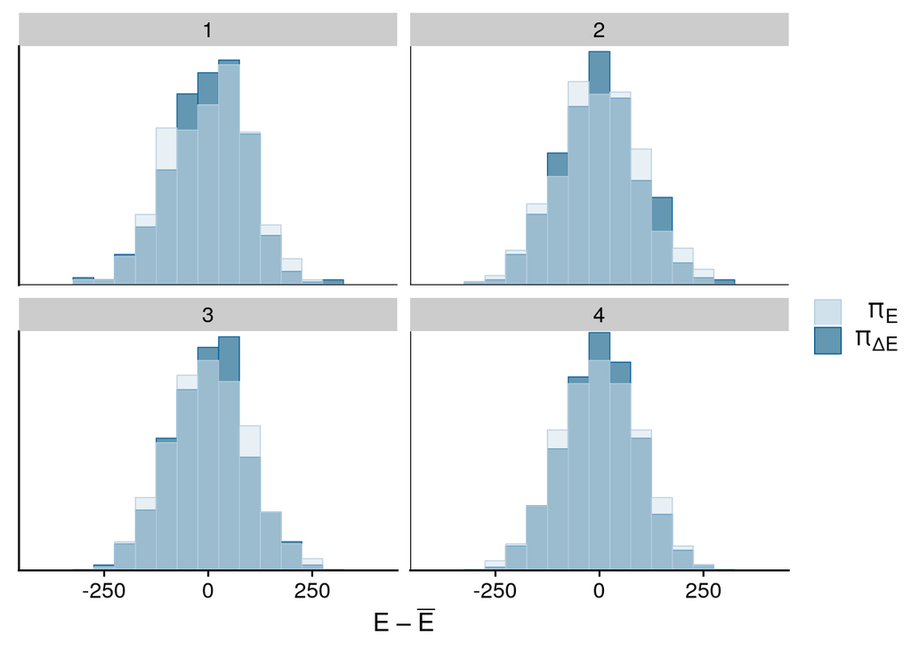

```r
pnbd_onlineretail_twohiermean_stanfit |>
  nuts_params() |>
  mcmc_nuts_energy(binwidth = 50)
```

## 2.3 Assess the Model

As we intend to run the same logic to assess each of our models, we have combined all this logic into a single function `run_model_assessment`, to run the simulations and combine the datasets.

```r
pnbd_stanfit <- pnbd_onlineretail_twohiermean_stanfit |>
  recover_types(customer_fit_stats_tbl)

pnbd_onlineretail_twohiermean_assess_data_lst <- run_model_assessment(
  model_stanfit    = pnbd_stanfit,
  insample_tbl     = customer_fit_subset_tbl,
  fit_label        = "pnbd_onlineretail_twohiermean",
  fit_end_dttm     = use_fit_end_date     |> as.POSIXct(),
  valid_start_dttm = use_valid_start_date |> as.POSIXct(),
  valid_end_dttm   = use_valid_end_date   |> as.POSIXct(),
  sim_seed         = 1210
  )

pnbd_onlineretail_twohiermean_assess_data_lst |> glimpse()
```

```
List of 5
 $ model_fit_index_filepath     : 'glue' chr "data/pnbd_onlineretail_twohiermean_assess_fit_index_tbl.rds"
 $ model_valid_index_filepath   : 'glue' chr "data/pnbd_onlineretail_twohiermean_assess_valid_index_tbl.rds"
 $ model_simstats_filepath      : 'glue' chr "data/pnbd_onlineretail_twohiermean_assess_model_simstats_tbl.rds"
 $ model_fit_simstats_filepath  : 'glue' chr "data/pnbd_onlineretail_twohiermean_assess_fit_simstats_tbl.rds"
 $ model_valid_simstats_filepath: 'glue' chr "data/pnbd_onlineretail_twohiermean_assess_valid_simstats_tbl.rds"
```

### 2.3.1 Check In-Sample Data Validation

We first check the model against the in-sample data.

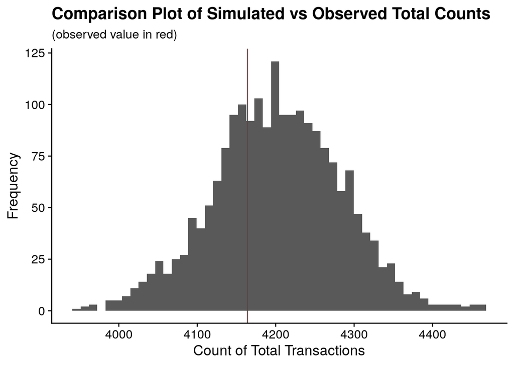

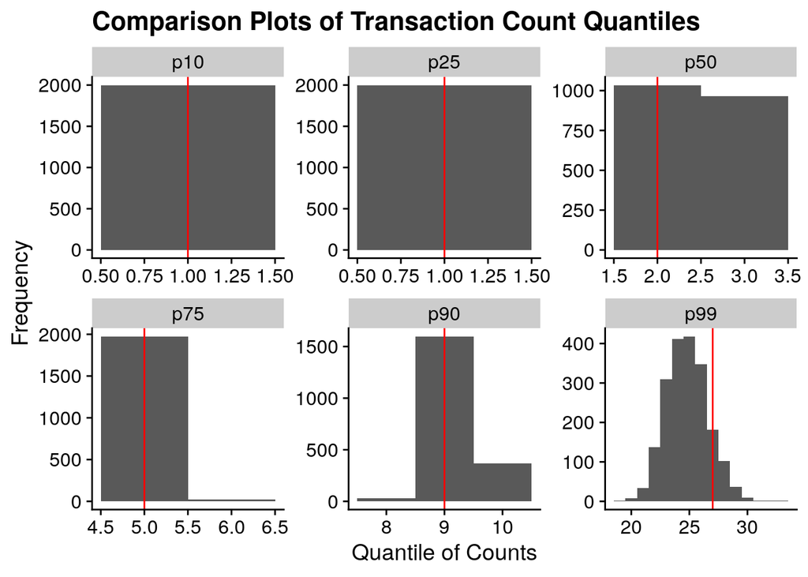

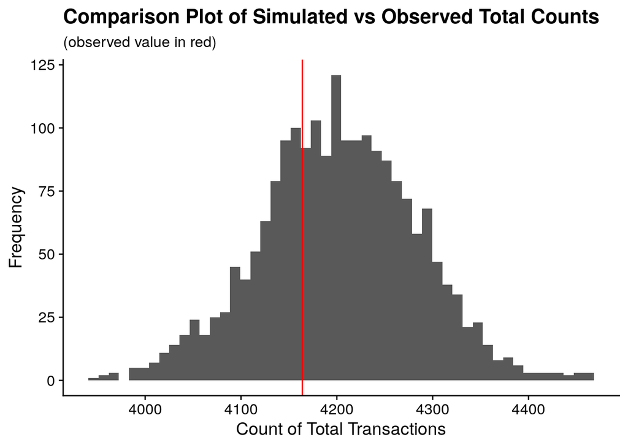

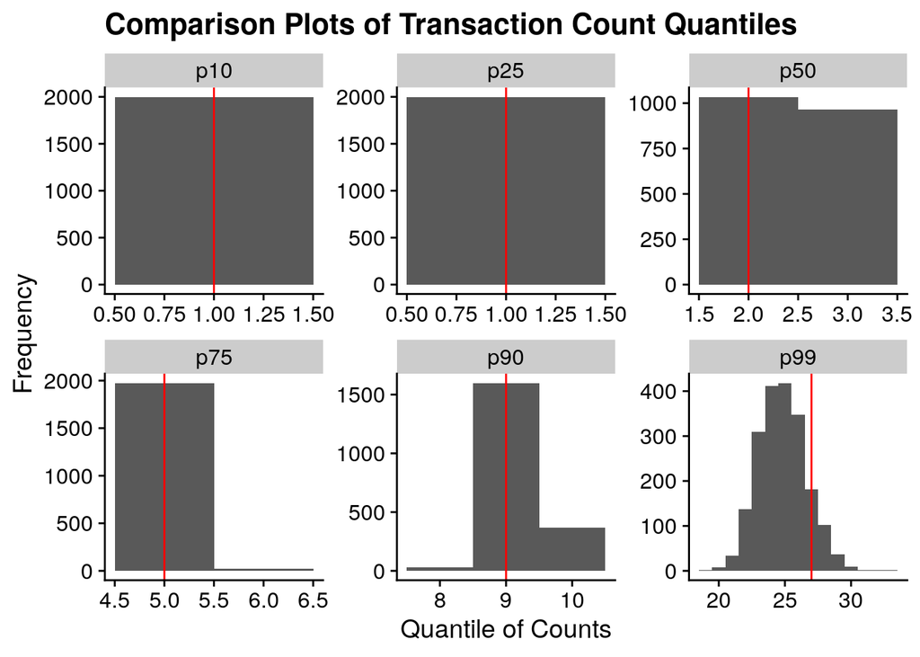

```r
simdata_tbl <- pnbd_onlineretail_twohiermean_assess_data_lst |>
  use_series(model_fit_index_filepath) |>
  read_rds() |>
  use_series(sim_file) |>
  map_dfr(read_rds) |>
  select(customer_id, draw_id, sim_data) |>
  unnest(sim_data) |>
  bind_rows(sim_init_tbl) |>
  arrange(customer_id, draw_id, tnx_timestamp)


assess_plots_lst <- create_model_assessment_plots(
  obsdata_tbl = customer_fit_transactions_tbl,
  simdata_tbl = simdata_tbl
  )

assess_plots_lst |> map(print)
```

### 2.3.2 Check Out-of-Sample Data Validation

We now repeat for the out-of-sample data.

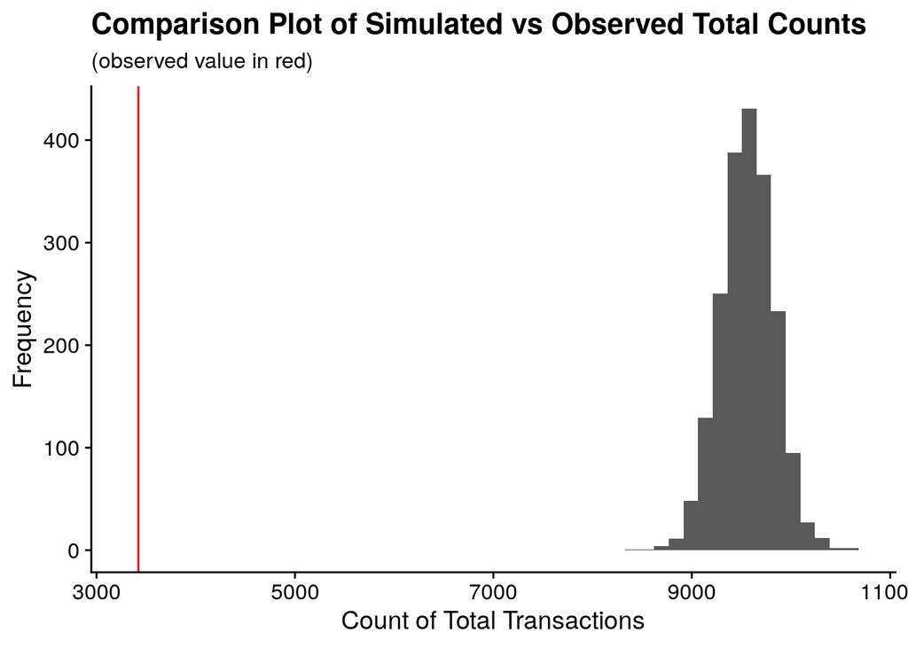

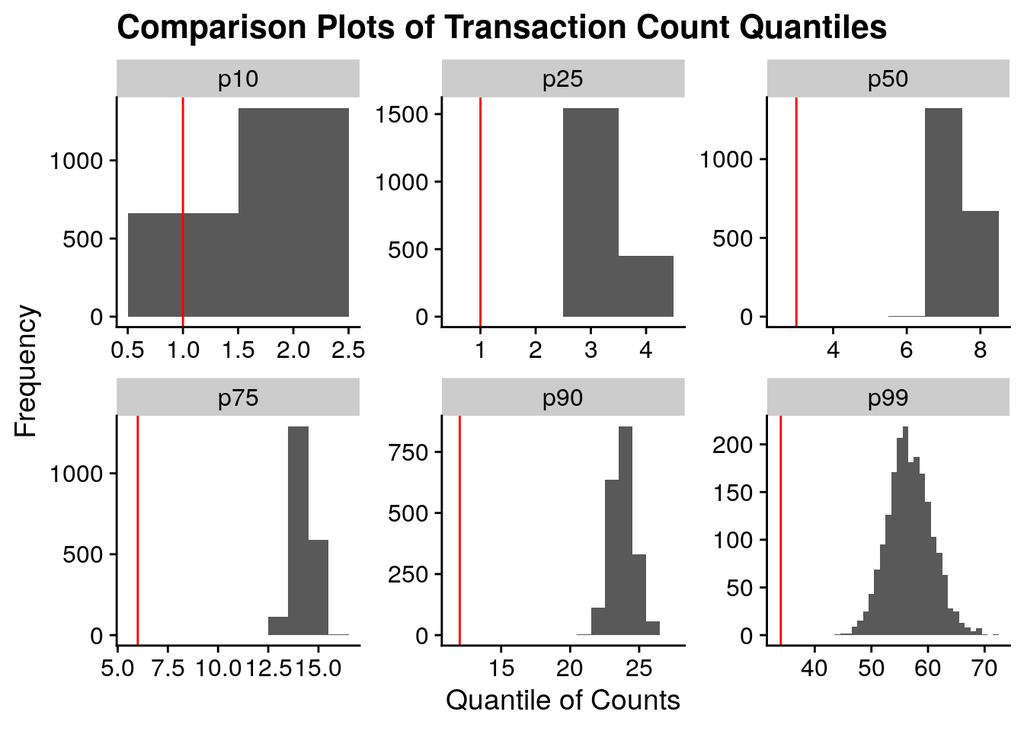

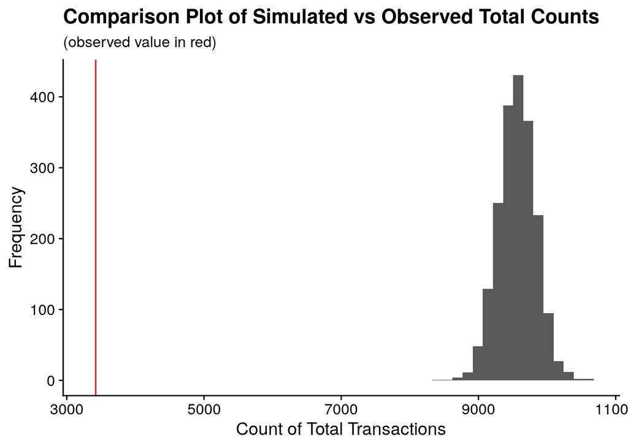

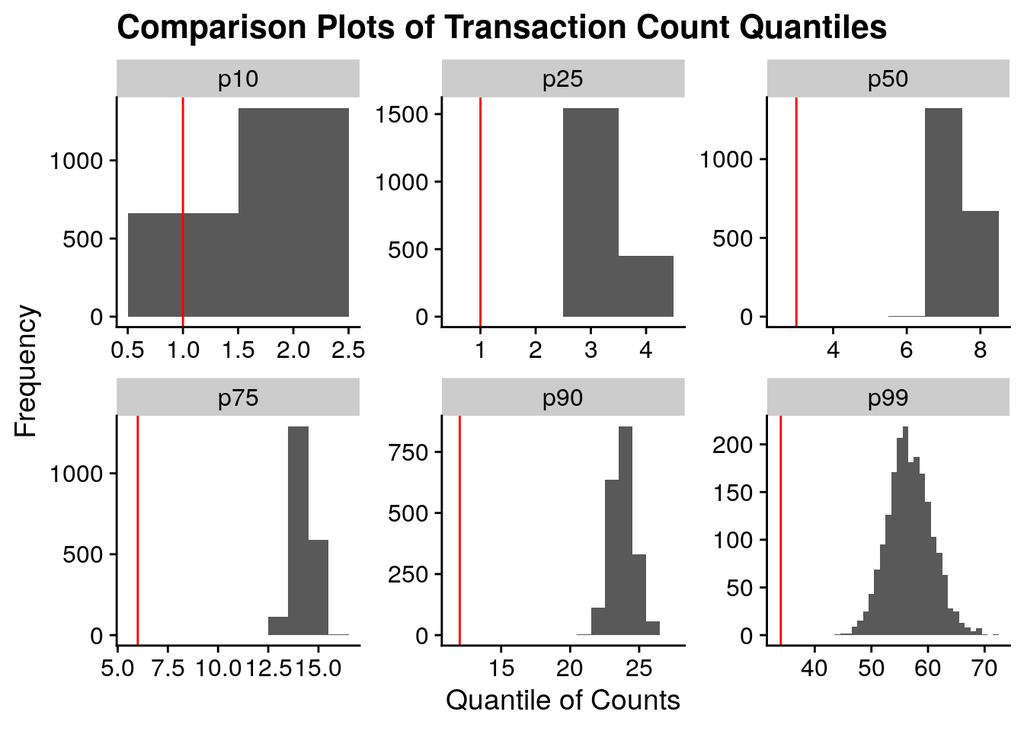

```r
simdata_tbl <- pnbd_onlineretail_twohiermean_assess_data_lst |>
  use_series(model_valid_index_filepath) |>
  read_rds() |>
  use_series(sim_file) |>
  map_dfr(read_rds) |>
  select(customer_id, draw_id, sim_data) |>
  unnest(sim_data) |>
  arrange(customer_id, draw_id, tnx_timestamp)


assess_plots_lst <- create_model_assessment_plots(
  obsdata_tbl = customer_valid_transactions_tbl,
  simdata_tbl = simdata_tbl
  )

assess_plots_lst |> map(print)
```

# 3 Fit Hierarchical Lambda Model

Our next model puts a hierarchical prior around both $\lambda$ parameters, `lambda_mn` and `lambda_cv`.

Once again we use a Gamma prior for both these parameters.

## 3.1 Compile and Fit Stan Model

We now compile this model using `CmdStanR`.

```r
pnbd_twohierlambda_stanmodel <- cmdstan_model(
  "stan_code/pnbd_twohier_lambda.stan",
  include_paths =   stan_codedir,
  pedantic      =           TRUE,
  dir           =  stan_modeldir
  )
```

We then use this compiled model with our data to produce a fit of the data.

```r
stan_modelname <- "pnbd_onlineretail_twohierlambda"
stanfit_prefix <- str_c("fit_", stan_modelname)
stanfit_seed   <- stanfit_seed + 1

stanfit_object_file <- glue("data/{stanfit_prefix}_stanfit.rds")


stan_data_lst <- customer_fit_stats_tbl |>
  select(customer_id, x, t_x, T_cal) |>
  compose_data(
    hier_lambda_mn_p1 = 0.25,
    hier_lambda_mn_p2 = 1.00,

    hier_lambda_cv_p1 = 1.00,
    hier_lambda_cv_p2 = 1.00,

    mu_mn             = 0.10,
    mu_cv             = 1.00
    )

if(!file_exists(stanfit_object_file)) {
  pnbd_onlineretail_twohierlambda_stanfit <- pnbd_twohierlambda_stanmodel$sample(
    data            =                stan_data_lst,
    chains          =                            4,
    iter_warmup     =                          500,
    iter_sampling   =                          500,
    seed            =                 stanfit_seed,
    save_warmup     =                         TRUE,
    output_dir      =                stan_modeldir,
    output_basename =               stanfit_prefix,
    )

  pnbd_onlineretail_twohierlambda_stanfit$save_object(stanfit_object_file, compress = "gzip")

} else {
  pnbd_onlineretail_twohierlambda_stanfit <- read_rds(stanfit_object_file)
}

pnbd_onlineretail_twohierlambda_stanfit$print()
```

```
  variable      mean    median    sd   mad        q5       q95 rhat ess_bulk
 lp__      -61263.76 -61265.75 91.06 96.52 -61412.90 -61113.30 1.01      350
 lambda_mn      0.13      0.13  0.00  0.00      0.12      0.13 1.00     1175
 lambda_cv      0.84      0.84  0.01  0.01      0.82      0.87 1.01      341
 lambda[1]      0.29      0.27  0.12  0.11      0.13      0.52 1.00     2243
 lambda[2]      0.50      0.49  0.09  0.09      0.36      0.65 1.00     2781
 lambda[3]      0.04      0.03  0.03  0.02      0.01      0.09 1.00     1740
 lambda[4]      1.36      1.36  0.15  0.15      1.12      1.61 1.00     2875
 lambda[5]      0.32      0.32  0.07  0.07      0.21      0.45 1.00     1971
 lambda[6]      0.24      0.24  0.06  0.07      0.15      0.35 1.00     1976
 lambda[7]      0.06      0.05  0.03  0.03      0.02      0.11 1.00     1603
 ess_tail
      738
     1654
      696
     1349
     1625
      822
     1569
     1489
     1185
     1106

 # showing 10 of 12722 rows (change via 'max_rows' argument or 'cmdstanr_max_rows' option)
```

We have some basic HMC-based validity statistics we can check.

```r
pnbd_onlineretail_twohierlambda_stanfit$cmdstan_diagnose()
```

```
Processing csv files: /home/rstudio/btydwork/stan_models/fit_pnbd_onlineretail_twohierlambda-1.csvWarning: non-fatal error reading adaptation data
, /home/rstudio/btydwork/stan_models/fit_pnbd_onlineretail_twohierlambda-2.csvWarning: non-fatal error reading adaptation data
, /home/rstudio/btydwork/stan_models/fit_pnbd_onlineretail_twohierlambda-3.csvWarning: non-fatal error reading adaptation data
, /home/rstudio/btydwork/stan_models/fit_pnbd_onlineretail_twohierlambda-4.csvWarning: non-fatal error reading adaptation data


Checking sampler transitions treedepth.
Treedepth satisfactory for all transitions.

Checking sampler transitions for divergences.
No divergent transitions found.

Checking E-BFMI - sampler transitions HMC potential energy.
E-BFMI satisfactory.

Effective sample size satisfactory.

Split R-hat values satisfactory all parameters.

Processing complete, no problems detected.
```

## 3.2 Visual Diagnostics of the Sample Validity

Now that we have a sample from the posterior distribution we need to create a few different visualisations of the diagnostics.

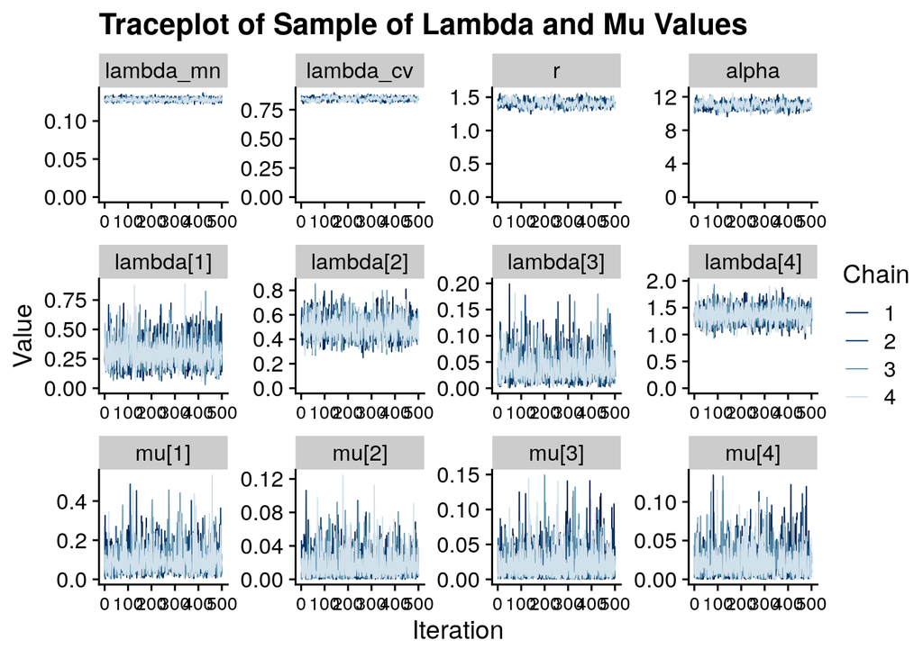

```r
parameter_subset <- c(
  "lambda_mn", "lambda_cv", "r", "alpha",
  "lambda[1]", "lambda[2]", "lambda[3]", "lambda[4]",
  "mu[1]",     "mu[2]",     "mu[3]",     "mu[4]"
  )

pnbd_onlineretail_twohierlambda_stanfit$draws(inc_warmup = FALSE) |>
  mcmc_trace(pars = parameter_subset) +
  expand_limits(y = 0) +
  labs(
    x = "Iteration",
    y = "Value",
    title = "Traceplot of Sample of Lambda and Mu Values"
    ) +
  theme(axis.text.x = element_text(size = 10))
```

We also check $N_{eff}$ as a quick diagnostic of the fit.

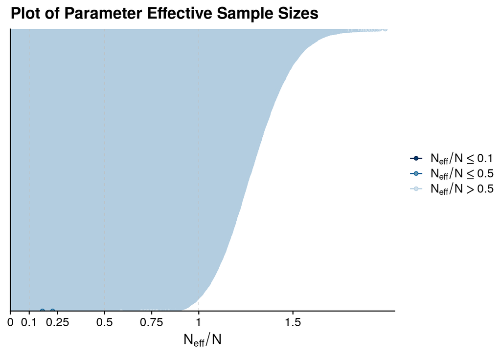

```r
pnbd_onlineretail_twohierlambda_stanfit |>
  neff_ratio(
    pars = c("lambda_mn", "lambda_cv", "r", "alpha", "lambda", "mu")
    ) |>
  mcmc_neff() +
    ggtitle("Plot of Parameter Effective Sample Sizes")
```

Finally, we want to check out the energy diagnostic, which is often indicative of problems with the posterior mixing.

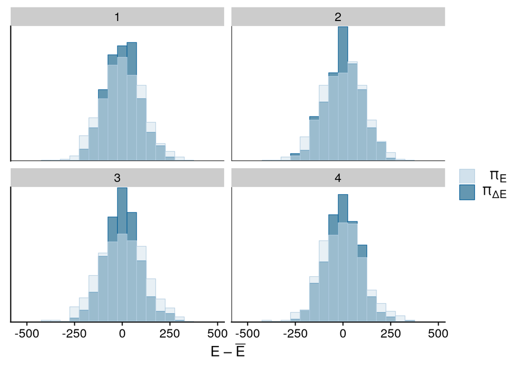

```r
pnbd_onlineretail_twohierlambda_stanfit |>
  nuts_params() |>
  mcmc_nuts_energy(binwidth = 50)
```

## 3.3 Assess the Model

As we intend to run the same logic to assess each of our models, we have combined all this logic into a single function `run_model_assessment`, to run the simulations and combine the datasets.

```r
pnbd_stanfit <- pnbd_onlineretail_twohierlambda_stanfit |>
  recover_types(customer_fit_stats_tbl)

pnbd_onlineretail_twohierlambda_assess_data_lst <- run_model_assessment(
  model_stanfit    = pnbd_stanfit,
  insample_tbl     = customer_fit_subset_tbl,
  fit_label        = "pnbd_onlineretail_twohierlambda",
  fit_end_dttm     = use_fit_end_date     |> as.POSIXct(),
  valid_start_dttm = use_valid_start_date |> as.POSIXct(),
  valid_end_dttm   = use_valid_end_date   |> as.POSIXct(),
  sim_seed         = 1220
  )

pnbd_onlineretail_twohierlambda_assess_data_lst |> glimpse()
```

```
List of 5
 $ model_fit_index_filepath     : 'glue' chr "data/pnbd_onlineretail_twohierlambda_assess_fit_index_tbl.rds"
 $ model_valid_index_filepath   : 'glue' chr "data/pnbd_onlineretail_twohierlambda_assess_valid_index_tbl.rds"
 $ model_simstats_filepath      : 'glue' chr "data/pnbd_onlineretail_twohierlambda_assess_model_simstats_tbl.rds"
 $ model_fit_simstats_filepath  : 'glue' chr "data/pnbd_onlineretail_twohierlambda_assess_fit_simstats_tbl.rds"
 $ model_valid_simstats_filepath: 'glue' chr "data/pnbd_onlineretail_twohierlambda_assess_valid_simstats_tbl.rds"
```

### 3.3.1 Check In-Sample Data Validation

We first check the model against the in-sample data.

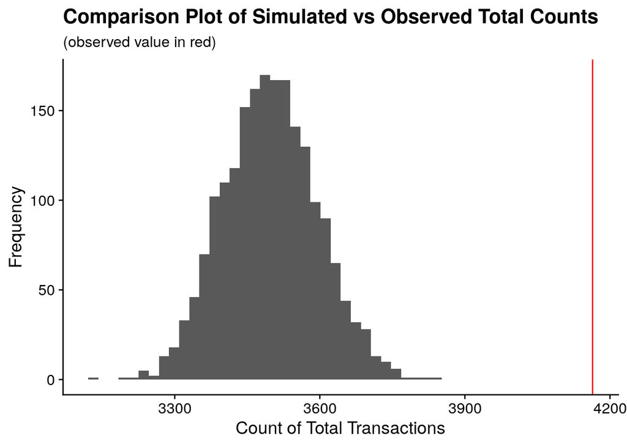

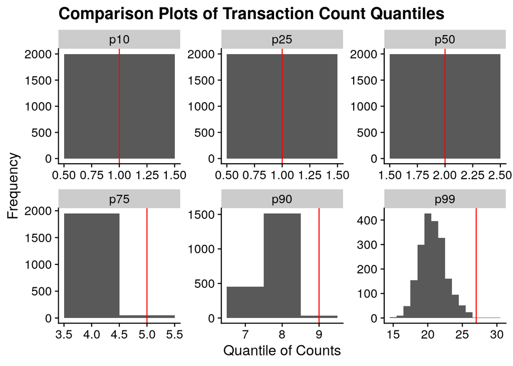

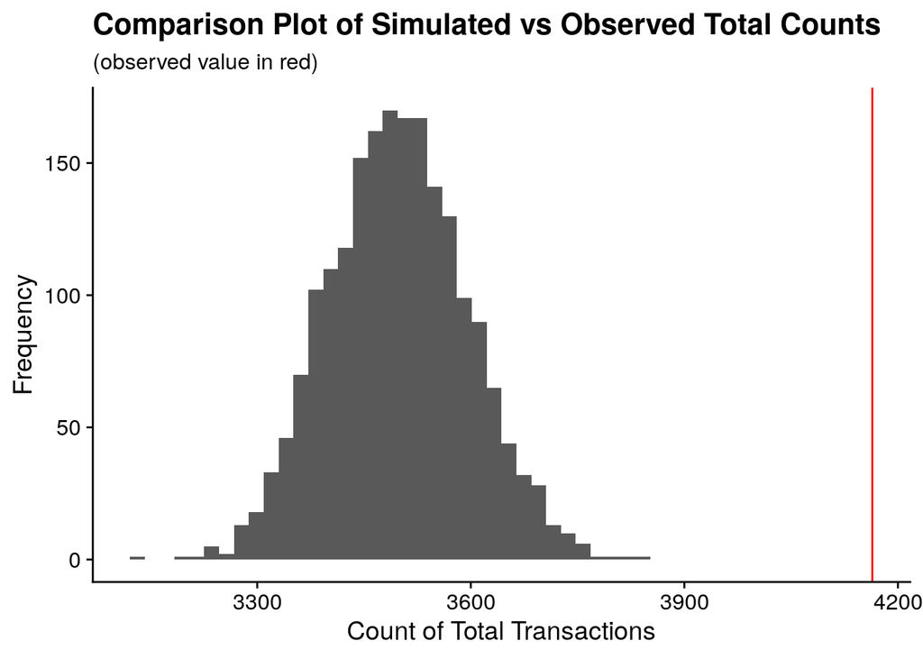

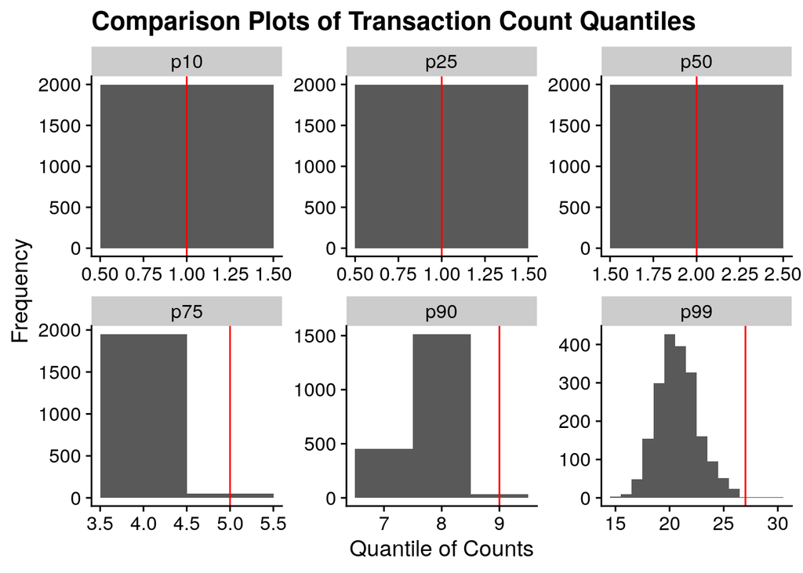

```r
simdata_tbl <- pnbd_onlineretail_twohierlambda_assess_data_lst |>
  use_series(model_fit_index_filepath) |>
  read_rds() |>
  use_series(sim_file) |>
  map_dfr(read_rds) |>
  select(customer_id, draw_id, sim_data) |>
  unnest(sim_data) |>
  bind_rows(sim_init_tbl) |>
  arrange(customer_id, draw_id, tnx_timestamp)


assess_plots_lst <- create_model_assessment_plots(
  obsdata_tbl = customer_fit_transactions_tbl,
  simdata_tbl = simdata_tbl
  )

assess_plots_lst |> map(print)
```

### 3.3.2 Check Out-of-Sample Data Validation

We now repeat for the out-of-sample data.

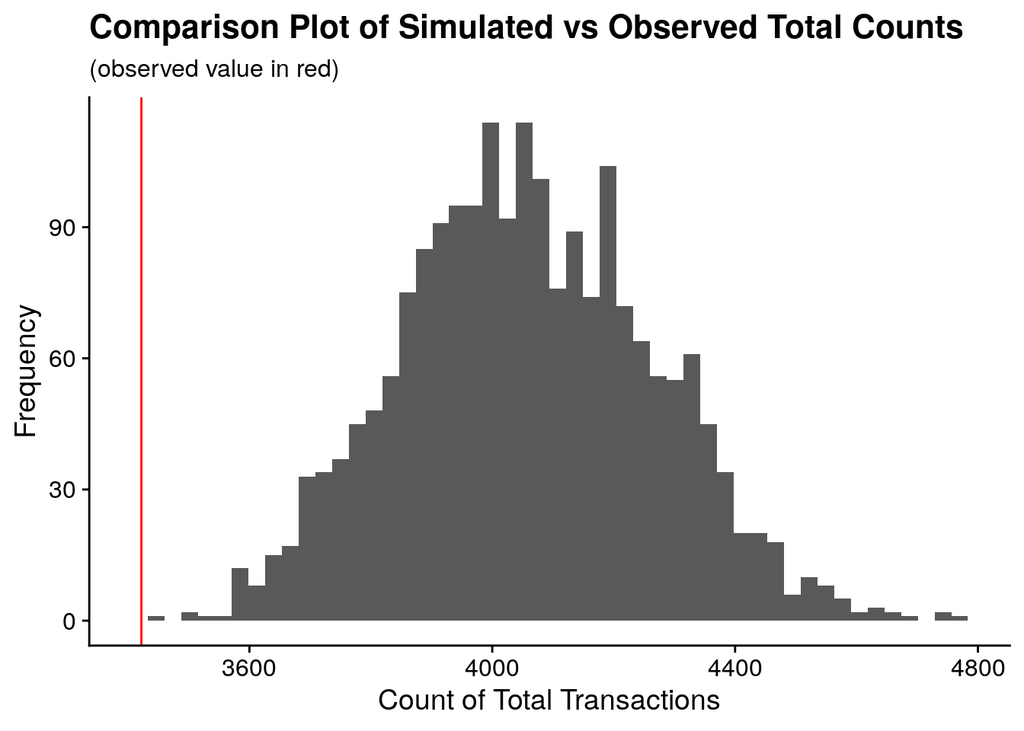

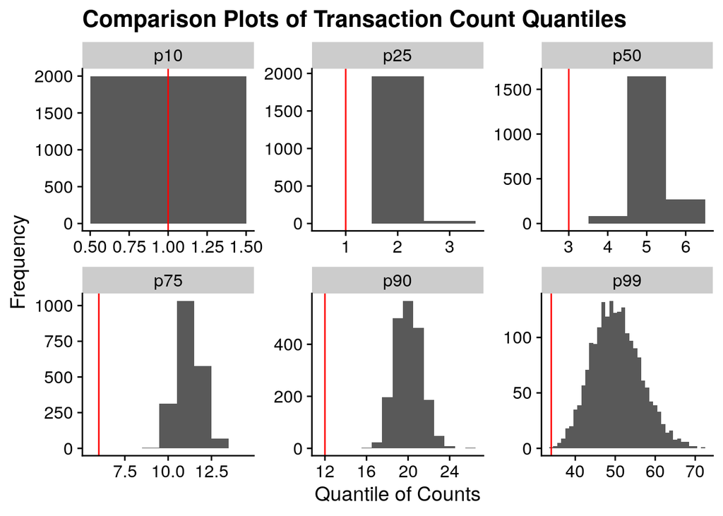

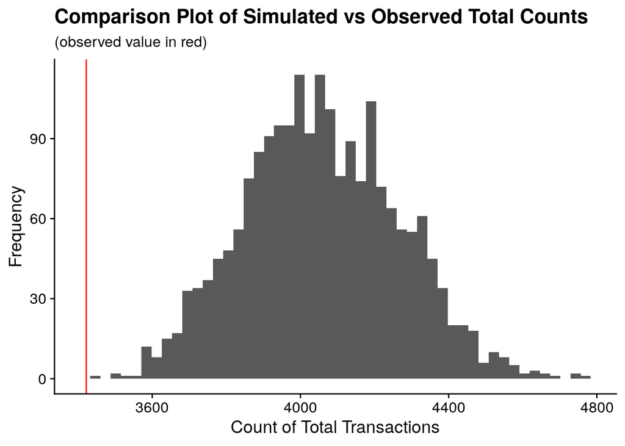

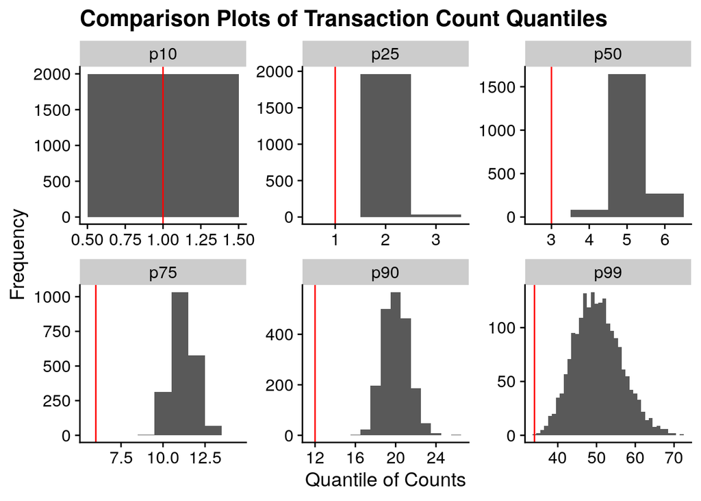

```r
simdata_tbl <- pnbd_onlineretail_twohierlambda_assess_data_lst |>
  use_series(model_valid_index_filepath) |>
  read_rds() |>
  use_series(sim_file) |>
  map_dfr(read_rds) |>
  select(customer_id, draw_id, sim_data) |>
  unnest(sim_data) |>
  arrange(customer_id, draw_id, tnx_timestamp)


assess_plots_lst <- create_model_assessment_plots(
  obsdata_tbl = customer_valid_transactions_tbl,
  simdata_tbl = simdata_tbl
  )

assess_plots_lst |> map(print)
```

# 4 Compare Model Outputs

We have looked at each of the models individually, but it is also worth looking at each of the models as a group.

We now want to combine both the `fit` and `valid` transaction sets to calculate the summary statistics for both.

```r
obs_summstats_tbl <- list(
    fit   = customer_fit_transactions_tbl,
    valid = customer_valid_transactions_tbl
    ) |>
  bind_rows(.id = "assess_type") |>
  group_by(assess_type) |>
  calculate_transaction_summary_statistics() |>
  pivot_longer(
    cols      = !assess_type,
    names_to  = "label",
    values_to = "obs_value"
    )

obs_summstats_tbl |> glimpse()
```

```
Rows: 16
Columns: 3
$ assess_type <chr> "fit", "fit", "fit", "fit", "fit", "fit", "fit", "fit", "v…
$ label       <chr> "p10", "p25", "p50", "p75", "p90", "p99", "total_count", "…
$ obs_value   <dbl> 1.000000, 1.000000, 2.000000, 5.000000, 9.000000, 27.01000…
```

```r
model_assess_transactions_tbl <- dir_ls("data", regexp = "pnbd_onlineretail_(fixed|one|two).*_assess_.*index") |>
  enframe(name = NULL, value = "file_path") |>
  mutate(
    model_label = str_replace(file_path, "data/pnbd_onlineretail_(.*?)_assess_.*", "\\1"),
    assess_type = if_else(str_detect(file_path, "_assess_fit_"), "fit", "valid"),

    assess_data = map(
      file_path, construct_model_assessment_data,

      .progress = "construct_assess_data"
      )
    ) |>
  select(model_label, assess_type, assess_data) |>
  unnest(assess_data)

model_assess_transactions_tbl |> glimpse()
```

```
Rows: 154,603,382
Columns: 6
$ model_label   <chr> "fixed1", "fixed1", "fixed1", "fixed1", "fixed1", "fixed…
$ assess_type   <chr> "fit", "fit", "fit", "fit", "fit", "fit", "fit", "fit", …
$ customer_id   <fct> 13078, 13078, 13078, 13078, 13078, 13078, 13078, 13078, …
$ draw_id       <int> 1, 1, 1, 1, 1, 1, 1, 1, 1, 1, 1, 1, 1, 1, 1, 1, 1, 1, 1,…
$ tnx_timestamp <dttm> 2009-12-01 12:50:44, 2010-01-10 17:25:42, 2010-01-20 11…
$ tnx_amount    <dbl> 113.06, 154.46, 130.47, 194.81, 104.02, 99.04, 83.73, 23…
```

We now want to calculate the transaction statistics on this full dataset, for each separate draw.

```r
model_assess_tbl <- model_assess_transactions_tbl |>
  group_by(model_label, assess_type, draw_id) |>
  calculate_transaction_summary_statistics()

model_assess_tbl |> glimpse()
```

```
Rows: 40,000
Columns: 11
$ model_label <chr> "fixed1", "fixed1", "fixed1", "fixed1", "fixed1", "fixed1"…
$ assess_type <chr> "fit", "fit", "fit", "fit", "fit", "fit", "fit", "fit", "f…
$ draw_id     <int> 1, 2, 3, 4, 5, 6, 7, 8, 9, 10, 11, 12, 13, 14, 15, 16, 17,…
$ p10         <dbl> 1, 1, 1, 1, 1, 1, 1, 1, 1, 1, 1, 1, 1, 1, 1, 1, 1, 1, 1, 1…
$ p25         <dbl> 1, 1, 1, 1, 1, 1, 1, 1, 1, 1, 1, 1, 1, 1, 1, 1, 1, 1, 1, 1…
$ p50         <dbl> 3, 3, 3, 3, 3, 3, 3, 3, 3, 3, 3, 3, 3, 3, 3, 3, 3, 3, 3, 3…
$ p75         <dbl> 5.00, 5.00, 6.00, 5.00, 5.00, 5.00, 5.00, 5.00, 6.00, 6.00…
$ p90         <dbl> 9.0, 9.0, 10.0, 10.0, 10.0, 11.0, 9.7, 10.0, 10.0, 10.0, 1…
$ p99         <dbl> 27.58, 26.76, 26.56, 26.33, 24.69, 25.49, 25.00, 26.02, 28…
$ total_count <int> 2812, 2692, 2822, 2680, 2747, 2891, 2847, 2792, 2834, 2817…
$ mean_count  <dbl> 4.373250, 4.391517, 4.529695, 4.542373, 4.346519, 4.677994…
```

We now combine all this data to create a number of different comparison plots for the various summary statistics.

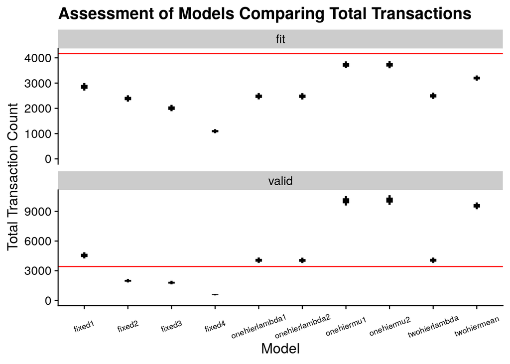

```r
#! echo: TRUE

create_multiple_model_assessment_plot(
  obs_summstats_tbl, model_assess_tbl,
  "total_count", "Total Transactions"
  )
```

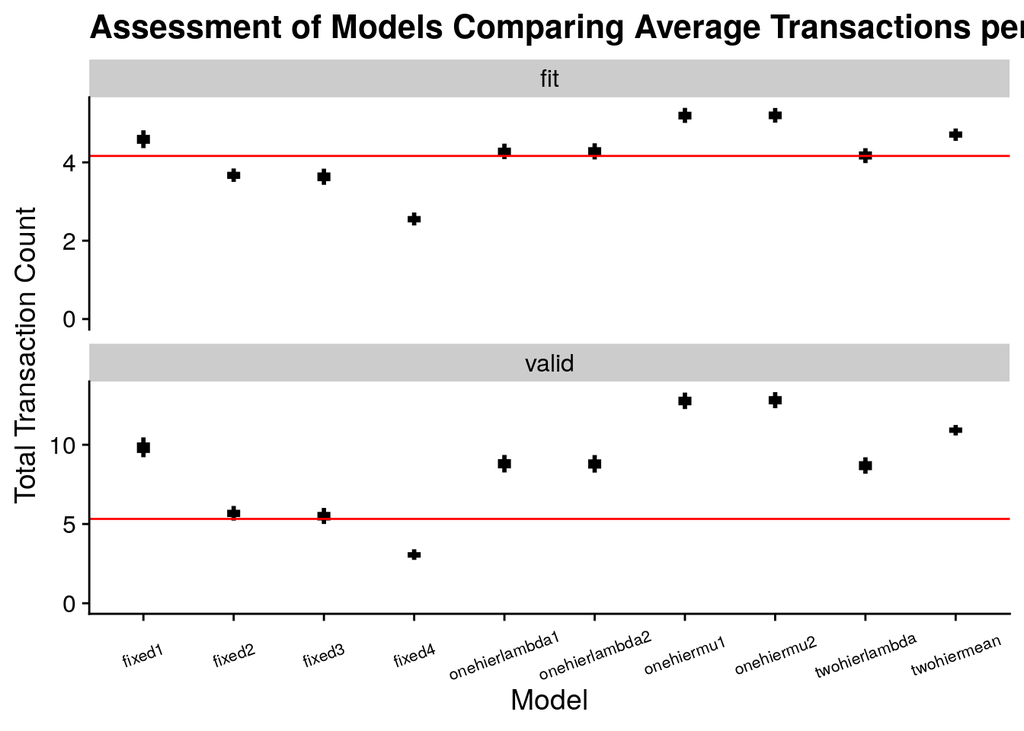

```r
create_multiple_model_assessment_plot(
  obs_summstats_tbl, model_assess_tbl,
  "mean_count", "Average Transactions per Customer"
  )
```

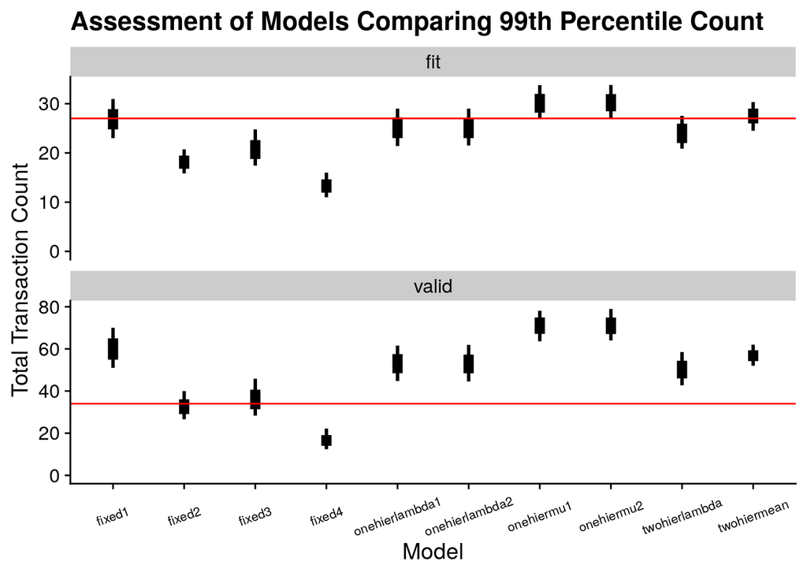

```r
create_multiple_model_assessment_plot(
  obs_summstats_tbl, model_assess_tbl,
  "p99", "99th Percentile Count"
  )
```

## 4.1 Write Assessment Data to Disk

We now want to save the assessment data to disk.

```r
model_assess_tbl |> write_rds("data/assess_data_pnbd_onlineretail_twohier_tbl.rds")
```

# R Environment

```r
options(width = 120L)
```

```r
options(width = 80L)
```